# Reproducible Research: Peer Assessment 1

Ricardo Estrada

Sunday, March 18, 2015

## Loading and preprocessing the data

```r
setwd("C:\\Users\\Rikhardo\\Documents\\Cursos\\Data Science\\5- Reproducible Research\\Assessment1")
#Load activity data from csv
activity_data <- read.csv("./activity.csv")
```

## What is mean total number of steps taken per day?

Histogram of the total number of steps taken each day

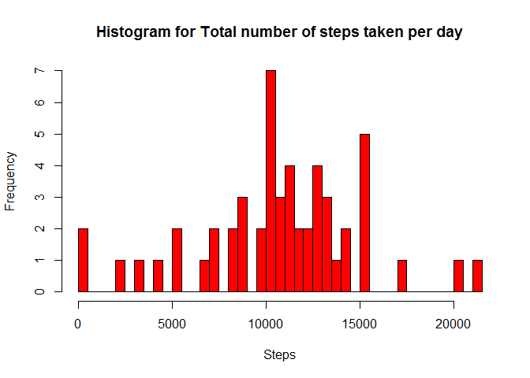

```r
activity_data_by_date <- aggregate(. ~ date, data = activity_data, FUN=sum)
activity_data_by_date$date_num <- as.numeric(activity_data_by_date$date)
hist(activity_data_by_date$steps, breaks =50, col=c("red"), xlab ="Steps", ylab = "Frequency", main="Histogram for Total number of steps taken per day")
```

```r
mean1 <- round(mean(activity_data_by_date$steps),2)
median1 <- median(activity_data_by_date$steps)
```

## What is the average daily activity pattern?

Time series plot of the 5-minute interval (X-axis) and the avg number of steps taken across all days (Y-axis) is plotted using the following R-code

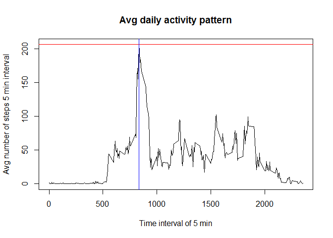

```r
activity_data_avg_steps_daily <- aggregate(activity_data$steps, by = list(activity_data$interval), FUN=mean, na.rm = T)
colnames(activity_data_avg_steps_daily) <- c("intervals", "mean")

max.steps <- max(activity_data_avg_steps_daily$mean)
max.int <- activity_data_avg_steps_daily[activity_data_avg_steps_daily$mean==max(max.steps),1]

plot(activity_data_avg_steps_daily$intervals, activity_data_avg_steps_daily$mean, xlab = "Time interval of 5 min", ylab = "Avg number of steps 5 min interval", type = "l", main = "Avg daily activity pattern")


abline(h=max.steps, col = c("red"))
abline(v=max.int, col = c("blue"))
```

The maximum number of steps per interval is 206.1698113 and corresponds to the interval 835

## Imputing missing values

1. Calculate and report the total number of missing values in the dataset (i.e. the total number of rows with NAs)

```r
 noofrows <- nrow(activity_data[is.na(activity_data$steps)==TRUE,])
```

There are 2304 rows with missing values

```r
## Copy original data into new dataframe
activity_data_new <- activity_data

## Copy the 5-min interval mean into all the missing values
row.names(activity_data_avg_steps_daily) <- activity_data_avg_steps_daily$intervals
ind <- which(is.na(activity_data_new$steps))
```

3. Create a new dataset that is equal to the original dataset but with the missing data filled in.

```r
activity_data_new[ind, 1] <- activity_data_new[as.factor(activity_data_new[ind,3]),2]
```

4.1 Make a histogram of the total number of steps taken each day

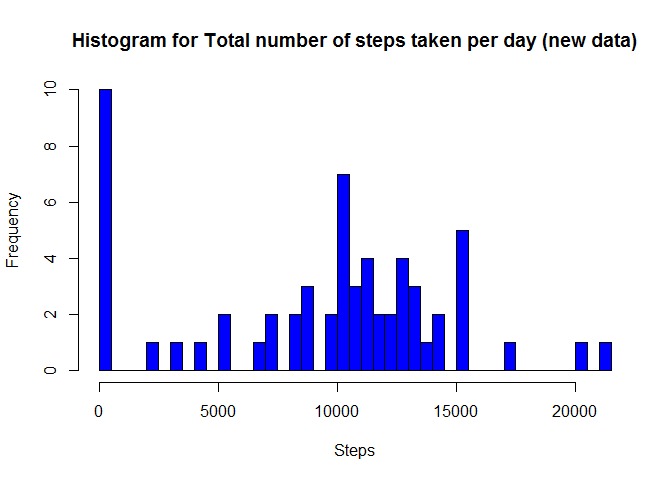

```r
activity_data_new_by_date <- aggregate(. ~ date, data = activity_data_new, FUN=sum)
hist(activity_data_new_by_date$steps, breaks=50, col=c("blue"), xlab ="Steps", ylab = "Frequency", main="Histogram for Total number of steps taken per day (new data)")
```

4.2 Calculate and report the mean and median total number of steps taken per day.

```r
mean(activity_data_new_by_date$steps)
```

```
## [1] 9392
```

[output not shown]

```r
median(activity_data_new_by_date$steps)
```

```
## [1] 10395
```

[output not shown]

## Are there differences in activity patterns between weekdays and weekends?

First we need to get the day information for the corresponding date given in the activity_data

```r
day_col <- weekdays(as.Date(activity_data_new$date))
day_col <- ifelse(day_col %in% c("Saturday","Sunday"), yes = "weekend", "weekday")
```

Saturday and Sunday are assigned as weekends and rest of the days as weekday

```r
x <- aggregate.data.frame(activity_data_new$steps, by = list(activity_data_new$interval, day_col), FUN = mean, na.rm = T)
colnames(x) <- c("interval", "daytype", "steps")
```

Panel plot containing a time series plot (i.e. type = “l”) of the 5-minute interval (x-axis) and the average number of steps taken, averaged across all weekday days or weekend days (y-axis).

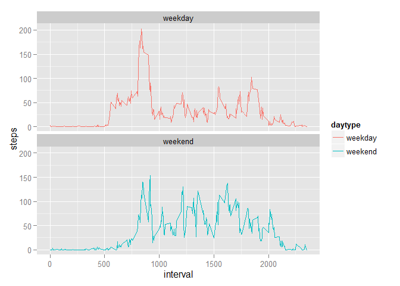

```r
library(ggplot2)
ggplot(data=x, aes(x=interval, y=steps, group=daytype)) + geom_line(aes(color=daytype)) + facet_wrap(~ daytype, nrow=2)
```